# Лабораторная работа № 5

Управление системными службами

Павличенко Родион Андреевич

1132246838@pfur.ru

Российский университет дружбы народов

2025-11-09

# Информация

## Докладчик

- Павличенко Родион Андреевич
- Cтудент
- Группа НПИбд-02-24
- Российский университет дружбы народов им. П. Лумумбы
- 1132246838@pfur.ru

# Выполнение лабораторной работы

## Получили полномочия администратора, проверили статус службы Very Secure FTP. Установили службу Very Secure FTP.

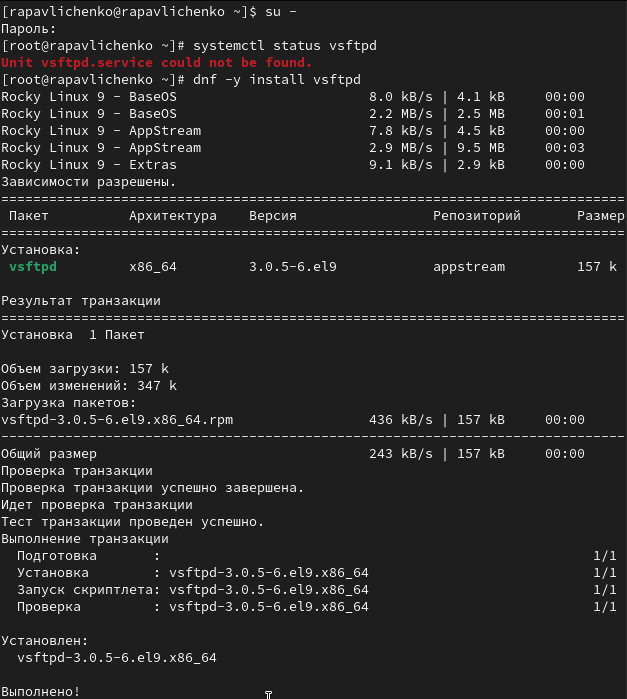

Рисунок 1: Проверка статуса

## Запустили службу Very Secure FTP. Проверили статус службы Very Secure FTP. Вывод команды должен показал, что служба в настоящее время работает, но не будет активирована при перезапуске операционной системы

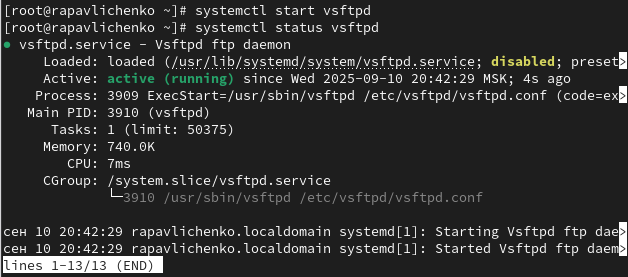

Рисунок 2: Работа со службой Very Secure FTP

## Добавили службу Very Secure FTP в автозапуск при загрузке операционной системы, используя команду systemctl enable. Затем проверили статус службы. Удалили службу из автозапуска, используя команду systemctl disable, и снова проверили её статус.

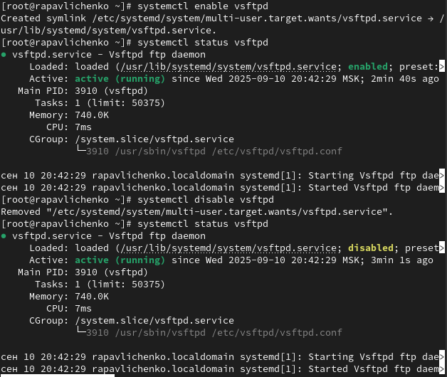

Рисунок 3: Работа со службой Very Secure FTP

## Вывели на экран символические ссылки, ответственные за запуск различных сервисов. Отобразилось, что ссылка на vsftpd.service не существует. Снова добавили службу Very Secure FTP в автозапуск: systemctl enable vsftpd и вывели на экран символические ссылки, ответственные за запуск различных сервисов. Вывод команды показал, что создана символическая ссылка для файла /usr/lib/systemd/system/vsftpd.service в каталоге /etc/systemd/system/multi-user.target.want

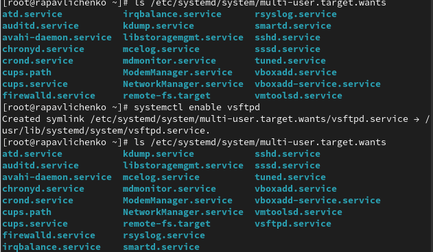

Рисунок 4: Вывод команды

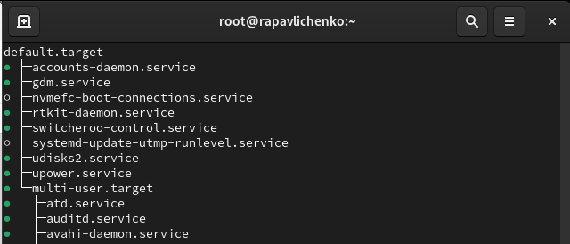

Рисунок 5: Вывод на экран списка зависимостей юнита

## Вывели на экран список юнитов, которые зависят от данного юнита

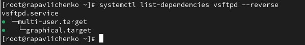

Рисунок 6: Вывод на экран списка зависимостей юнита

## Получили полномочия администратора. Установили iptables

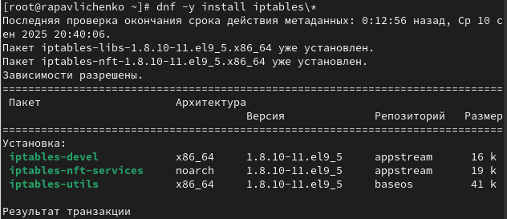

Рисунок 7: Установка iptables

## Проверили статус firewalld и iptables

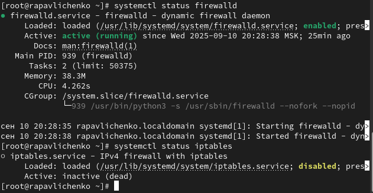

Рисунок 8: Проверка статуса firewalld и iptables

## Попробовали запустить firewalld и iptables. Мы увидели, что при запуске одной службы вторая дезактивируется или не запускается

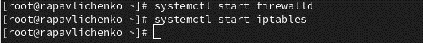

Рисунок 9: Запуск firewalld и iptables

## Ввели cat /usr/lib/systemd/system/firewalld.service и заметили, что в разделе conflicts присутствует iptables. Такую же команду выполнили для iptables, но конфликты там не были указаны.

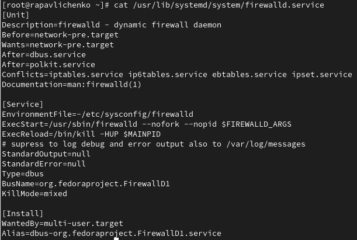

Рисунок 10: Работа с командами

## Выгрузили службу iptables (на всякий случай, чтобы убедиться, что данная служба не загружена в систему) и загрузили службу firewalld. Заблокировали запуск iptables, введя: systemctl mask iptables. Попробовали запустить iptables, появилось сообщение об ошибке, указывающее, что служба замаскирована и по этой причине не может быть запущена. Попробовали добавить iptables в автозапуск, сервис был неактивен, а статус загрузки отобразился как замаскированный

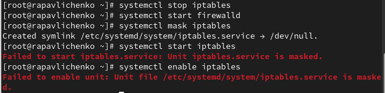

Рисунок 11: Блокировка запуска iptables

## Получили полномочия администратора. Перешли в каталог systemd и нашли список всех целей, которые можно изолировать

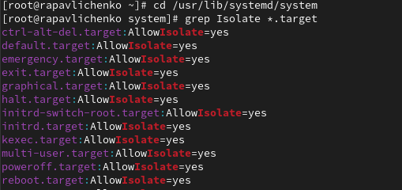

Рисунок 12: Поиск целей, которые можно изолировать

## Переключили операционную систему в режим восстановления

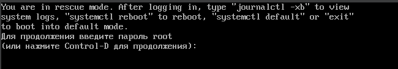

Рисунок 13: Переключение операционной системы в режим восстановления

## Получили полномочия администратора. Вывели на экран цель, установленную по умолчанию, для запуска по умолчанию текстового режима, ввели systemctl set-default multi-user.target Перезагрузили систему командой reboot

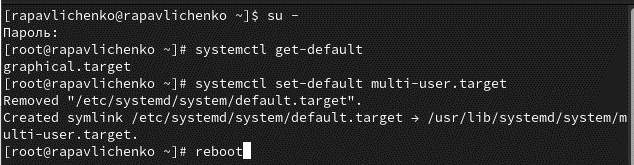

Рисунок 14: Текстовый режим

## Получили полномочия администратора. Для запуска по умолчанию графического режима введите systemctl set-default graphical.target Вновь перегрузили систему командой reboot. Убедились, что система загрузилась в графическом режиме

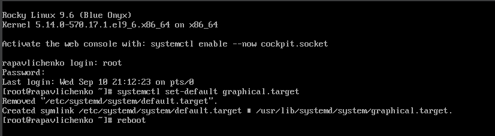

Рисунок 15: Перезагрузка системы в графический режим